# Phenology Modelling

#### 3.2. MODIS MCD12Q2 and spatial comparison

```r
# --- MODIS MCD12Q2 phenology over MA–NH region (2012) ---

modis_ma_nh <- mt_subset(
product   = "MCD12Q2",
band      = "Greenup.Num_Modes_01",
lat       = 43,
lon       = -71,
start     = "2012-01-01",
end       = "2012-12-31",
km_lr     = 100,         # ~100 km around the point
km_ab     = 100,
site_name = "ma_nh_2012",
internal  = TRUE,
progress  = FALSE
)

# Convert MODIS values from "days since 1970-01-01" to DOY,

# remove fill values and clearly unrealistic dates

modis_ma_nh <- modis_ma_nh |>
mutate(
value = ifelse(value > 32656, NA, value),                                   # fill values
value = as.numeric(format(as.Date("1970-01-01") + value, "%j")),            # -> DOY
value = ifelse(value < 200, value, NA_real_)                                # keep spring green-up only
)

# Tidy data frame -> SpatRaster

modis_ma_nh_rast <- mt_to_terra(
df        = modis_ma_nh,
reproject = TRUE   # to lon/lat
)

modis_ma_nh_rast
```

```
## class       : SpatRaster
## dimensions  : 209, 527, 1  (nrow, ncol, nlyr)
## resolution  : 0.00799757, 0.00799757  (x, y)
## extent      : -73.14335, -68.92863, 42.16184, 43.83333  (xmin, xmax, ymin, ymax)
## coord. ref. : lon/lat WGS 84 (EPSG:4326)
## source(s)   : memory
## name        : 2012-01-01
## min value   :   67.43407
## max value   :  141.00000
```

```r
# --- Align MODIS raster with model grid and compute difference ---

# Crop MODIS to the same extent as the model prediction

modis_ma_nh_crop <- crop(
modis_ma_nh_rast,
predicted_phenology_tri
)

# Resample MODIS to the model resolution

modis_resampled <- resample(
modis_ma_nh_crop,
predicted_phenology_tri,
method = "bilinear"
)

# Difference map (MODIS – model)

diff_map <- modis_resampled - predicted_phenology_tri

# Simple sanity check statistics (optional)

global(diff_map, fun = "mean", na.rm = TRUE)
```

```
##                 mean
## 2012-01-01 -77.24955
```

```r
global(diff_map, fun = "sd",   na.rm = TRUE)
```

```
##                  sd
## 2012-01-01 6.966619
```

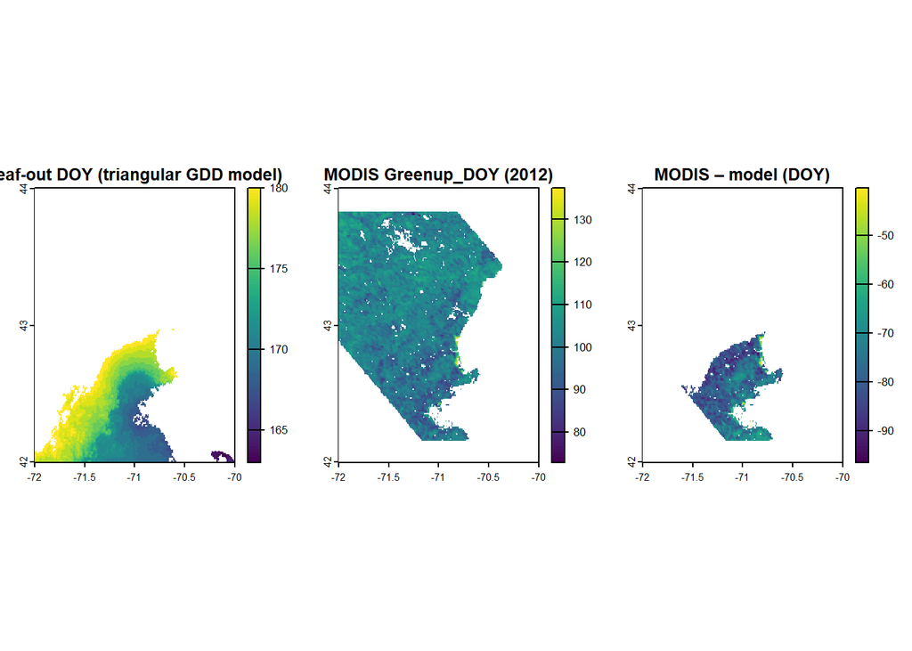

```r
# Plot: model, MODIS and difference

par(mfrow = c(1, 3))
plot(predicted_phenology_tri, main = "Leaf-out DOY (triangular GDD model)")
plot(modis_resampled,        main = "MODIS Greenup_DOY (2012)")
plot(diff_map,               main = "MODIS – model (DOY)")
```

```r
par(mfrow = c(1, 1))



# --- Align MODIS raster with model grid and compute difference ---

# Crop MODIS to the same extent as the model prediction

modis_ma_nh_crop <- crop(
modis_ma_nh_rast,
predicted_phenology_tri
)

# Resample MODIS to the model resolution

modis_resampled <- resample(
modis_ma_nh_crop,
predicted_phenology_tri,
method = "bilinear"
)

# Difference map (MODIS – model)

diff_map <- modis_resampled - predicted_phenology_tri

# Simple sanity check statistics (optional)

global(diff_map, fun = "mean", na.rm = TRUE)
```

```
##                 mean
## 2012-01-01 -77.24955
```

```r
global(diff_map, fun = "sd",   na.rm = TRUE)
```

```
##                  sd
## 2012-01-01 6.966619
```

```r
# Plot: model, MODIS and difference

par(mfrow = c(1, 3))
plot(predicted_phenology_tri, main = "Leaf-out DOY (triangular GDD model)")
plot(modis_resampled,        main = "MODIS Greenup_DOY (2012)")
plot(diff_map,               main = "MODIS – model (DOY)")
par(mfrow = c(1, 1))
```

[output not shown]

##### **Spatial comparison with MODIS MCD12Q2**

To evaluate the model at regional scale, we compared leaf-out dates predicted by the triangular GDD model for 2012 with MODIS MCD12Q2 Greenup_DOY. MODIS represents the first sustained increase in canopy greenness detected from satellite reflectance, while the model estimates physiological leaf-out based solely on temperature forcing.

### 4. Focus on year 2010

```r
modis_harvard <- mt_subset(
  product   = "MCD12Q2",
  band      = "Greenup.Num_Modes_01",
  lat       = harvard_lat,
  lon       = harvard_lon,
  start     = paste0(min(harvard_phenology$year), "-01-01"),
  end       = paste0(max(harvard_phenology$year), "-12-31"),
  km_lr     = 0,
  km_ab     = 0,
  site_name = "harvard_ts",
  internal  = TRUE,
  progress  = FALSE
)

modis_harvard_ts <- modis_harvard |>
  mutate(
    value = ifelse(value > 32656, NA, value),
    date  = as.Date("1970-01-01") + value,
    year  = as.numeric(format(date, "%Y")),
    doy   = as.numeric(format(date, "%j"))
  ) |>
  dplyr::group_by(year) |>
  dplyr::summarise(
    greenup_doy = mean(doy, na.rm = TRUE)
  ) |>
  filter(!is.na(greenup_doy))

modis_harvard_ts
```

```
## # A tibble: 15 × 2
##     year greenup_doy
##    <dbl>       <dbl>
##  1  2008         115
##  2  2009         109
##  3  2010          84
##  4  2011         109
##  5  2012         106
##  6  2013         110
##  7  2014         116
##  8  2015         115
##  9  2016         120
## 10  2017         115
## 11  2018         114
## 12  2019         115
## 13  2020         104
## 14  2021         105
## 15  2022         118
```

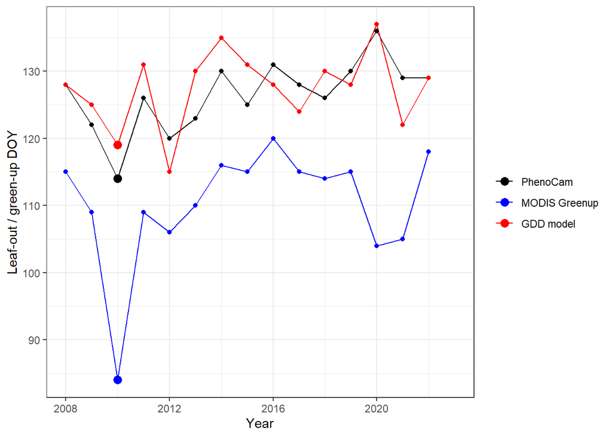

```r
comparison_point <- validation |>
  dplyr::left_join(modis_harvard_ts, by = "year")


comparison_point_long <- comparison_point |>
  select(year, doy, prediction, greenup_doy) |>
  pivot_longer(
    cols      = c(doy, prediction, greenup_doy),
    names_to  = "source",
    values_to = "DOY"
  )

ggplot(comparison_point_long, aes(year, DOY, colour = source)) +
  geom_line() +
  geom_point() +
  geom_point(
    data = subset(comparison_point_long, year == 2010),
    size = 3
  ) +
  scale_colour_manual(
    values = c("doy" = "black",
               "prediction" = "red",
               "greenup_doy" = "blue"),
    labels = c("doy"         = "PhenoCam",
               "prediction"  = "GDD model",
               "greenup_doy" = "MODIS Greenup")
  ) +
  labs(
    x = "Year",
    y = "Leaf-out / green-up DOY",
    colour = NULL
  ) +
  theme_bw()
```

```r
anomalies_2010 <- comparison_point_long |>
  dplyr::group_by(source) |>
  mutate(
    DOY_anom = DOY - mean(DOY, na.rm = TRUE)
  ) |>
  filter(year == 2010)

anomalies_2010
```

```
## # A tibble: 3 × 4
## # Groups:   source [3]
##    year source        DOY DOY_anom
##   <dbl> <chr>       <dbl>    <dbl>
## 1  2010 doy           114   -12.5
## 2  2010 prediction    119    -8.47
## 3  2010 greenup_doy    84   -26.3
```

##### **2010 as a special year in the northeastern United States**

The year 2010 was anomalously warm across the northeastern United States due to a strong positive phase of the North Atlantic Oscillation (NAO), reduced cold-air outbreaks and early snowmelt. Winter and early-spring temperatures were several degrees above average, producing extremely early GDD accumulation and advancing physiological leaf-out.

### 5. Conclusion

This exercise demonstrates how simple temperature-based phenology models can be calibrated using ground observations and applied across regions using gridded climate data. Although conceptually straightforward, the baseline GDD model underestimates interannual variability and cannot capture spatial heterogeneity observed by MODIS. Implementing a more realistic triangular thermal response did not improve performance, highlighting limitations imposed by data availability, species diversity and winter processes such as chilling.

The comparison with MODIS MCD12Q2 shows systematic offsets and spatial inconsistencies rooted in conceptual differences between satellite greenness and physiological leaf-out. The anomalous spring of 2010 further emphasises how climatic extremes can diverge model-based and satellite-based phenology. Future work could integrate chilling requirements, photoperiod sensitivity or species-specific parameters to better represent the complexity of temperate forest phenology.

### References

Chuine, I. (2000). A unified model for budburst of trees. *Journal of Theoretical Biology, 207*(3), 337–347. https://doi.org/10.1006/jtbi.2000.2178

Hufkens, K., Friedl, M. A., Sonnentag, O., Braswell, B. H., Milliman, T., & Richardson, A. D. (2012). Linking near-surface and satellite remote sensing measurements of deciduous broadleaf forest phenology. *Remote Sensing of Environment, 117*, 307–321. https://doi.org/10.1016/j.rse.2011.10.006

Maurya, J. P., & Bhalerao, R. P. (2017). Photoperiod- and temperature-mediated control of growth cessation and dormancy in trees: A molecular perspective. *Annals of Botany, 120*(3), 351–360. https://doi.org/10.1093/aob/mcx061

Morisette, J. T., Richardson, A. D., Knapp, A. K., Fisher, J. I., Graham, E. A., Abatzoglou, J., … Liang, L. (2009). Tracking the rhythm of the seasons in the face of global change: Phenological research in the 21st century. *Frontiers in Ecology and the Environment, 7*(5), 253–260. https://doi.org/10.1890/070217

Richardson, A. D., Hufkens, K., Milliman, T., & Aubrecht, D. M. (2013). Evaluating vegetation phenology using time-lapse cameras: Bridging the gap to remote sensing. *Remote Sensing of Environment, 144*, 85–95. https://doi.org/10.1016/j.rse.2013.01.028